# Problem Dependent Modelling Example: Google Stock Price

2025-07-07

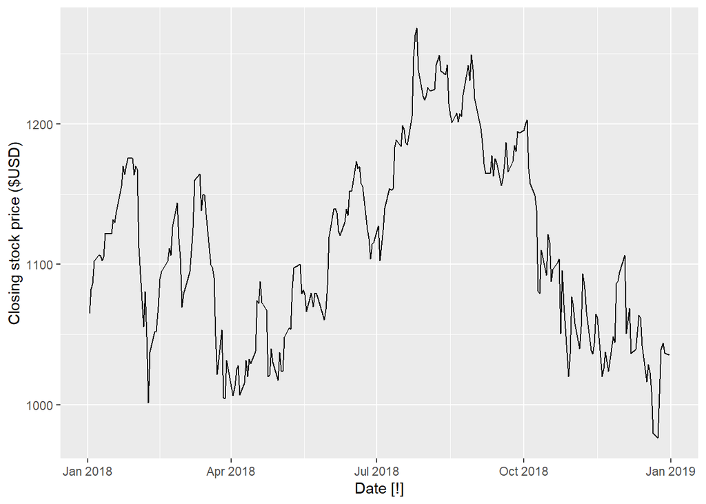

```r
google_2018 <- gafa_stock |>
  filter(Symbol == "GOOG", year(Date) == 2018)
google_2018 |>
  autoplot(Close) +
  labs(y = "Closing stock price ($USD)")
```

We see a series that seems quite eradic. To understand it better, we plot the autocorrelation function (acf):

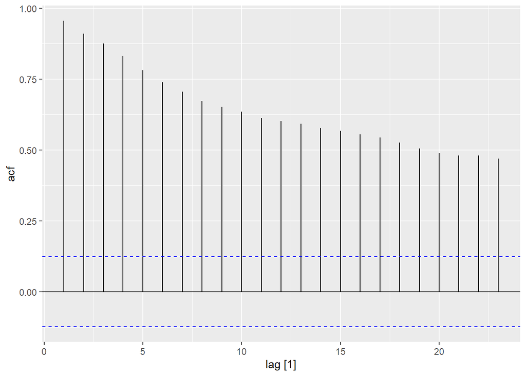

```r
google_2018 |>
  ACF(Close) |>
  autoplot()
```

We see that there is a clear (linear) dependence between $Y_t$ and its lags $Y_{t-h}$, even up to $h=20$. However, let’s see what happens if we use first differencing:

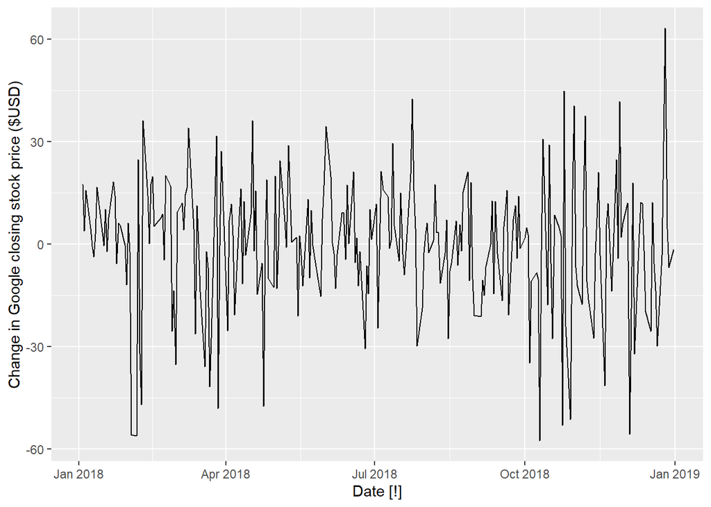

```r
google_2018 |>
  autoplot(difference(Close)) +
  labs(y = "Change in Google closing stock price ($USD)")
```

The plot now corresponds to the **change** in Google’s stock prices in USD. We see that this looks a lot like independent noise! To assess whether $Y_t$ and its lags $Y_{t-h}$ are independent, we again check the acf function:

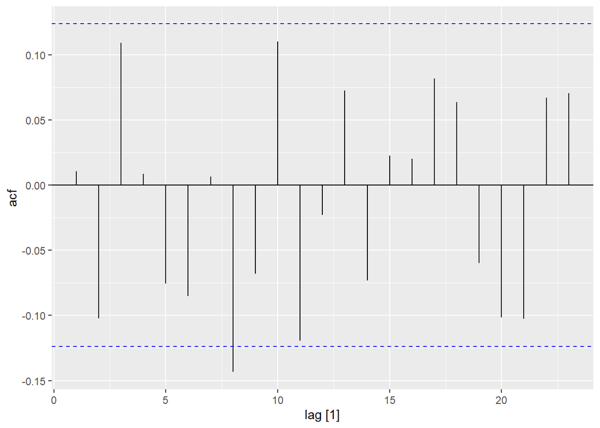

```r
google_2018 |>
  ACF(difference(Close)) |>
  autoplot()
```

After differencing, the acf values are as we would expect for an independent series ($5\%$ of violations are expected). However since the acf is only able to deal with linear dependence, we also employ a more general, the distance autocorrelation measure to double check:

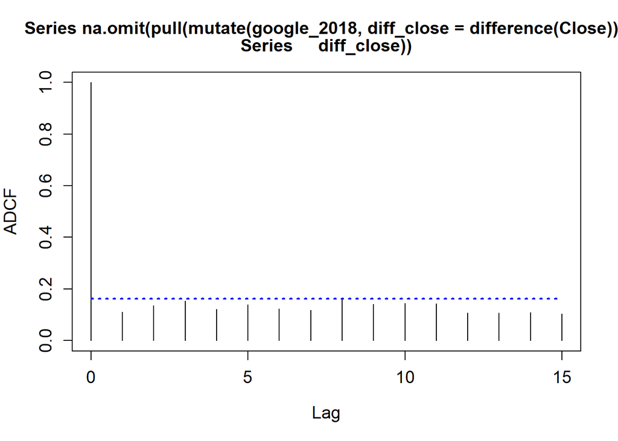

```
## $ADCF
##    lag 0     lag 1     lag 2     lag 3     lag 4     lag 5     lag 6     lag 7
##        1 0.1104512 0.1349239 0.1529571 0.1206196 0.1383774 0.1229415 0.1179289
##        lag 8     lag 9   lag 10    lag 11    lag 12    lag 13    lag 14
##    0.1649527 0.1410956 0.144709 0.1426128 0.1071056 0.1075994 0.1096857
##       lag 15
##    0.1030599
##
## $bootMethod
## [1] "Wild Bootstrap"
##
## $critical.values
## [1] 0.1623776
```

```r
google_2018 |>
  mutate(diff_close = difference(Close)) |>
  pull(diff_close) |>
  na.omit() |>
  ADCFplot()
```

## Fit and Predict an AR(1) model on data

We now implement an AR(1) model from scratch, touching on several things we will see later in the course. First we define the likelihood as in the slides:

```r
  # Conditional log-likelihood function
  # L(phi, sigma^2) = product of N(phi * y_{t-1}, sigma^2) for t = 2, ..., n
  log_likelihood <- function(params, y) {
    n<-length(y)
    phi <- params[1]
    log_sigma <- params[2]  # log(sigma) for numerical stability
    sigma <- exp(log_sigma)

    # Conditional mean: phi * Y_{t-1}
    mu <- phi * y[1:(n-1)]

    # Log-likelihood: sum of log-densities
    ll <- sum(dnorm(y[2:n], mean = mu, sd = sigma, log = TRUE))

    return(-ll)  # Return negative for minimization
  }
```

Now we can optimize this likelihood over the data:

```r
fit_ar1 <- function(y) {
  n <- length(y)
  # Optimize
  result <- optim(par = c(0, 0), fn = log_likelihood, y=y, method = "BFGS")

  phi_hat <- result$par[1]
  sigma_hat <- exp(result$par[2])

  return(list(
    phi = phi_hat,
    sigma = sigma_hat,
    loglik = -result$value,
    convergence = result$convergence
  ))
}
```

```r
# Example Usage with Google data

# Fit AR(1) model
ar1_model <- fit_ar1(google_2018$Close)

cat("AR(1) Model Results:\n")
```

```
## AR(1) Model Results:
```

```r
cat("phi =", round(ar1_model$phi, 4), "\n")
```

```
## phi = 0.9998
```

```r
cat("sigma =", round(ar1_model$sigma, 4), "\n")
```

```
## sigma = 19.2676
```

```r
cat("Log-likelihood =", round(ar1_model$loglik, 2), "\n")
```

```
## Log-likelihood = -1094.31
```

Now we use simulation to predict 10 steps into the future. That is we define the simulation algorithm given our model above:

```r
simulate_ar1 <- function(model, last_value, h = 10, n_sim = 1000) {
  phi <- model$phi
  sigma <- model$sigma

  # Matrix to store simulations (n_sim x h)
  sims <- matrix(NA, nrow = n_sim, ncol = h)

  for(i in 1:n_sim) {
    y_sim <- numeric(h)
    y_current <- last_value

    for(t in 1:h) {
      # Generate next value: Y_t = phi * Y_{t-1} + epsilon_t
      epsilon <- rnorm(1, mean = 0, sd = sigma)
      y_sim[t] <- phi * y_current + epsilon
      y_current <- y_sim[t]
    }

    sims[i, ] <- y_sim
  }

  return(sims)
}
```

We now use this to define a prediction object that contains the (conditional) expectation prediction as well as a prediction interval:

```r
predict_ar1 <- function(model, last_value, h = 10, n_sim = 1000,
                       confidence_levels = c(80, 95)) {

  sims <- simulate_ar1(model, last_value, h, n_sim)

  # Calculate point forecasts (mean)
  point_forecast <- colMeans(sims)

  # Calculate prediction intervals for specified confidence levels
  lower_matrix <- matrix(NA, nrow = h, ncol = length(confidence_levels))
  upper_matrix <- matrix(NA, nrow = h, ncol = length(confidence_levels))

  for(i in seq_along(confidence_levels)) {
    cl <- confidence_levels[i]
    alpha <- (100 - cl) / 100
    lower_matrix[, i] <- apply(sims, 2, quantile, probs = alpha/2)
    upper_matrix[, i] <- apply(sims, 2, quantile, probs = 1 - alpha/2)
  }

  return(list(
    point_forecast = point_forecast,
    lower = lower_matrix,
    upper = upper_matrix,
    levels = confidence_levels,
    simulations = sims
  ))
}
```

We use this to predict:

```r
# Generate predictions
last_obs <- tail(google_2018$Close, 1)
predictions <- predict_ar1(ar1_model, last_obs, h = 10, n_sim = 1000)

#point forecasts (conditional expectations)
paste("Point Forecasts:")
```

```
## [1] "Point Forecasts:"
```

```r
predictions$point_forecast
```

```
##  [1] 1036.358 1035.700 1035.701 1034.713 1034.964 1034.032 1034.193 1034.584
##  [9] 1035.002 1035.456
```

```r
# lower CI
paste("Lower Prediction Interval:")
```

```
## [1] "Lower Prediction Interval:"
```

```r
predictions$lower
```

```
##            [,1]     [,2]
##  [1,] 1011.2806 997.6169
##  [2,]  998.1133 979.1544
##  [3,]  991.4650 969.4851
##  [4,]  985.3716 957.7339
##  [5,]  975.2345 949.7724
##  [6,]  967.4799 936.3462
##  [7,]  964.9459 929.4263
##  [8,]  960.2188 924.7409
##  [9,]  954.8141 915.8449
## [10,]  955.0211 913.6257
```

```r
# higher CI
paste("Upper Prediction Interval:")
```

```
## [1] "Upper Prediction Interval:"
```

```r
predictions$upper
```

```
##           [,1]     [,2]
##  [1,] 1061.214 1075.613
##  [2,] 1072.537 1093.638
##  [3,] 1079.936 1099.432
##  [4,] 1085.115 1112.115
##  [5,] 1090.682 1120.270
##  [6,] 1097.676 1124.849
##  [7,] 1102.183 1133.595
##  [8,] 1109.383 1138.436
##  [9,] 1112.440 1145.964
## [10,] 1113.049 1152.097
```

```r
# Simulated values:
paste("Simulated Future Values:")
```

```
## [1] "Simulated Future Values:"
```

```r
head(predictions$simulations)
```

```
##           [,1]      [,2]      [,3]      [,4]      [,5]      [,6]      [,7]
## [1,] 1045.0160 1036.9502 1033.2745 1026.8606 1042.8565 1051.9161 1045.8035
## [2,] 1061.2291 1059.0700 1052.6025 1015.4484 1002.7289  975.5157 1012.4822
## [3,]  982.9413  981.7888  981.6359  957.7831  962.3796  993.0686  992.1373
## [4,] 1074.5776 1086.8250 1111.2048 1098.8245 1124.5689 1156.5160 1178.8241
## [5,] 1013.6041 1024.6688 1026.1319 1021.3880 1049.7999 1042.7163 1050.5233
## [6,] 1029.2230 1022.8883 1039.6727 1003.0865 1016.9444 1031.9234 1035.4211
##          [,8]      [,9]     [,10]
## [1,] 1040.050 1058.6823 1055.1180
## [2,] 1021.124 1031.0323 1030.0689
## [3,] 1011.725 1003.7654 1004.8114
## [4,] 1178.650 1203.5109 1201.4200
## [5,] 1009.849  983.1924  969.7599
## [6,] 1052.912 1076.5705 1063.1782
```

This is a bit technical, but given these predictions we can define a forecast object that plays together nicely with the autoplot function of the fable package we will use.

```r
create_forecast_object <- function(y, predictions, start_time = NULL) {
  n <- length(y)
  h <- length(predictions$point_forecast)

  # If no start_time provided, assume simple indexing
  if(is.null(start_time)) {
    start_forecast = n + 1
    end_forecast = n + h
  } else {
    start_forecast = start_time
    end_forecast = start_time + h - 1
  }

  # Create forecast object structure
  forecast_obj <- structure(
    list(
      mean = ts(predictions$point_forecast, start = start_forecast, end = end_forecast),
      lower = predictions$lower,
      upper = predictions$upper,
      level = predictions$levels,
      x = ts(y),  # original data as time series
      method = "AR(1) - Manual Implementation"
    ),
    class = "forecast"
  )

  return(forecast_obj)
}
```

```r
ar1_forecast <- create_forecast_object(google_2018$Close, predictions)

# Display predictions
cat("\n10-step ahead predictions:\n")
```

```
##
## 10-step ahead predictions:
```

```r
for(i in 1:10) {
  cat("Step", i, ": ", round(predictions$point_forecast[i], 4),
      " [", round(predictions$lower[i, 2], 4), ", ",
      round(predictions$upper[i, 2], 4), "]\n")
}
```

```
## Step 1 :  1036.358  [ 997.6169 ,  1075.613 ]
## Step 2 :  1035.7  [ 979.1544 ,  1093.639 ]
## Step 3 :  1035.701  [ 969.4851 ,  1099.432 ]
## Step 4 :  1034.713  [ 957.7339 ,  1112.115 ]
## Step 5 :  1034.964  [ 949.7724 ,  1120.27 ]
## Step 6 :  1034.032  [ 936.3462 ,  1124.849 ]
## Step 7 :  1034.193  [ 929.4263 ,  1133.595 ]
## Step 8 :  1034.584  [ 924.7409 ,  1138.436 ]
## Step 9 :  1035.002  [ 915.8449 ,  1145.964 ]
## Step 10 :  1035.456  [ 913.6257 ,  1152.097 ]
```

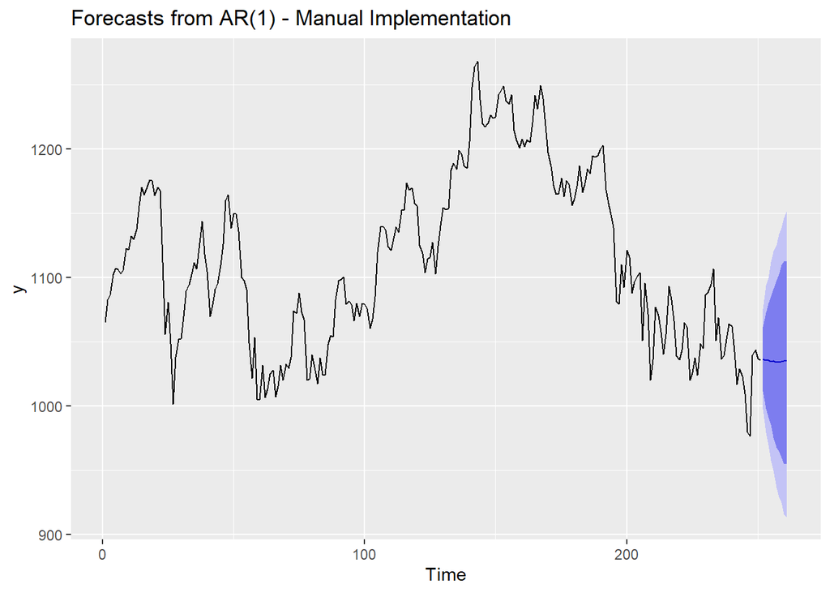

```r
# Now you can use autoplot!
library(forecast)
library(ggplot2)

# Plot using autoplot
autoplot(ar1_forecast)
```

Now we do the same using the nice fable package:

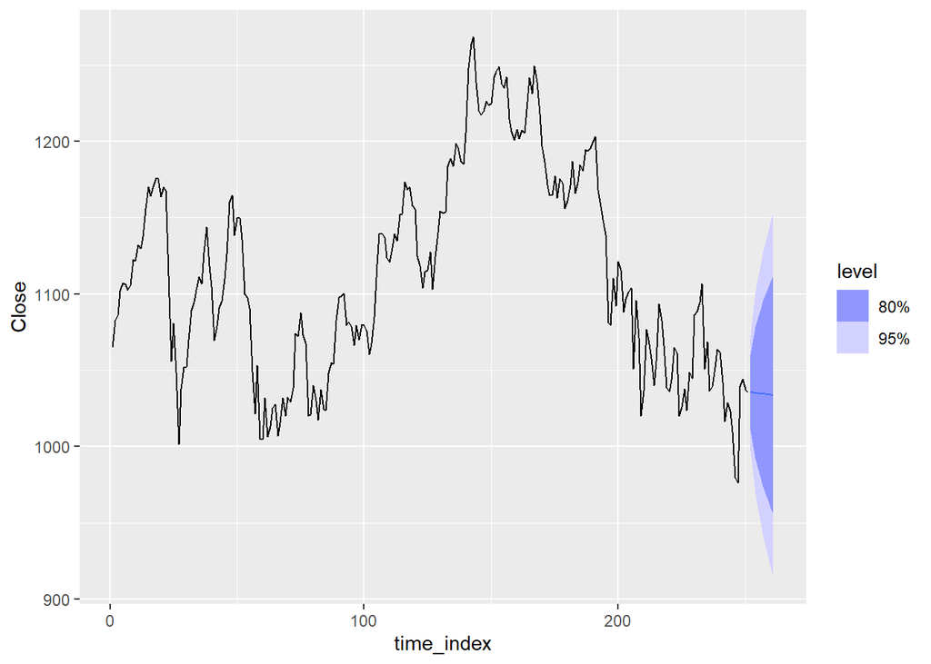

```r
# First make the time series regular (basically map to {1,...,T})
google_simple <- google_2018 |>
  mutate(time_index = row_number()) |>
  as_tsibble(index = time_index, regular = TRUE)

fit <- google_simple |>
  model(ARIMA(Close~0+pdq(1,0,0)))

fit |>
  forecast(h=10) |>
  autoplot(google_simple)
```

## Nonparametric Alternative: Fit and Predict DRF on data*

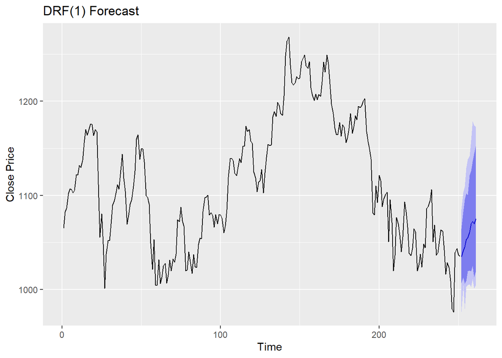

```r
## This will not work well here though!
library(drf)
source("drfown.R")

H<-10
n<-length(google_2018$Close)
X<-as.matrix(google_2018$Close[1:(n-1)])
Y<-as.matrix(google_2018$Close[2:n])

fit<-drfown(X=X, Y=Y)

B<-100

Ypred<-matrix(NaN, nrow=H+1, ncol=B)
Ypred[1,]<-rep(google_2018$Close[n],B)

##Predict a path
for (b in 1:B){

  for (h in 2:(H+1)){
    # start from last (h-1) prediction in the same "world" b
  DRFw <- predict(fit, newdata =Ypred[h-1,b] )$weights
  ## Draw path
  sig<-abs(n^(-1/5)/drf:::medianHeuristic(Y))
  mean<-Y[sample(1:nrow(Y), size=1, replace = T, DRFw[1,])]

  Ypred[h,b]<-rnorm(n=1, mean = mean, sd =sig )

  }

}


point_forecasts <- rowMeans(Ypred[2:(H+1),]) #pred_matrix[, "Point Forecast"]
lower_80 <- apply(Ypred[2:(H+1),], 1, quantile, probs = 0.1 )  #pred_matrix[, "Lo 80"]
upper_80 <- apply(Ypred[2:(H+1),], 1, quantile, probs = 0.9 ) #pred_matrix[, "Hi 80"]
lower_95 <- apply(Ypred[2:(H+1),], 1, quantile, probs = 0.025 ) #pred_matrix[, "Lo 95"]
upper_95 <- apply(Ypred[2:(H+1),], 1, quantile, probs = 0.975 )

# Create a manual forecast object
manual_forecast <- structure(
  list(
    mean = ts(point_forecasts, start=n+1, end=n+H),
    lower = cbind(lower_80, lower_95),
    upper = cbind(upper_80, upper_95),
    level = c(80, 95),
    x = ts(google_2018$Close)  # your original data
  ),
  class = "forecast"
)

# Plot it
autoplot(manual_forecast) +
  labs(title = "DRF(1) Forecast",
       y = "Close Price",
       x = "Time")
```